# Exploration and Analysis of NOAA Storm Database

akshayamrit

25/08/2019

# Exploration and Analysis of NOAA Storm Database to Identify Most Harmful Events With Respect to Population Health and Economic Consequences

Storm Data is an official publication of the National Oceanic and Atmospheric Administration (NOAA) which documents:  
1. The occurrence of storms and other significant weather phenomena having sufficient intensity to cause loss of life, injuries, significant property damage, and/or disruption to commerce.  
2. Rare, unusual, weather phenomena that generate media attention, such as snow flurries in South Florida or the San Diego coastal area.  
3. Other significant meteorological events, such as record maximum or minimum temperatures or precipitation that occur in connection with another event.  
According to NOAA, the data recording starts from Jan 1950. Data which we are using contains data from Jan 1950 to Nov 2011. Storm Data contains Date, Time, Event, Place of occurance, Damage, etc. We will be using this database to identify most harmful events with respect to population health as well as economic consequences.

## Data Processing:

Before we get into the analysis, we will check whether we have the data or not. If the data is not present in our working directory, it will be downloaded.

```r
if(!file.exists("StormData.csv.bz2")) {
      download.file(url = "https://d396qusza40orc.cloudfront.net/repdata%2Fdata%2FStormData.csv.bz2",
                    destfile = "StormData.csv.bz2", method = "curl")
}
if(!file.exists("StromDataDoc.pdf")){
      download.file(url = "https://d396qusza40orc.cloudfront.net/repdata%2Fpeer2_doc%2Fpd01016005curr.pdf",
                    destfile = "StromDataDoc.pdf", method = "curl")
}
```

We made sure that we have the data so we can start reading the data now. We will be reading the pdf documentation as well to extract categorized event types.

```r
library(data.table)
readTime <- proc.time()
stormData <- fread("StormData.csv.bz2")
proc.time()-readTime
```

```
##    user  system elapsed
##   31.57    2.03   81.63
```

```r
rm(readTime)
```

We have loaded the data but we need to know what the data looks like and isolate the data needed to answer our questions.

```r
dim(stormData)
```

```
## [1] 902297     37
```

```r
str(stormData)
```

```
## Classes 'data.table' and 'data.frame':   902297 obs. of  37 variables:
##  $ STATE__   : num  1 1 1 1 1 1 1 1 1 1 ...
##  $ BGN_DATE  : chr  "4/18/1950 0:00:00" "4/18/1950 0:00:00" "2/20/1951 0:00:00" "6/8/1951 0:00:00" ...
##  $ BGN_TIME  : chr  "0130" "0145" "1600" "0900" ...
##  $ TIME_ZONE : chr  "CST" "CST" "CST" "CST" ...
##  $ COUNTY    : num  97 3 57 89 43 77 9 123 125 57 ...
##  $ COUNTYNAME: chr  "MOBILE" "BALDWIN" "FAYETTE" "MADISON" ...
##  $ STATE     : chr  "AL" "AL" "AL" "AL" ...
##  $ EVTYPE    : chr  "TORNADO" "TORNADO" "TORNADO" "TORNADO" ...
##  $ BGN_RANGE : num  0 0 0 0 0 0 0 0 0 0 ...
##  $ BGN_AZI   : chr  "" "" "" "" ...
##  $ BGN_LOCATI: chr  "" "" "" "" ...
##  $ END_DATE  : chr  "" "" "" "" ...
##  $ END_TIME  : chr  "" "" "" "" ...
##  $ COUNTY_END: num  0 0 0 0 0 0 0 0 0 0 ...
```

[output cut: 24 more lines]

```r
length(unique(stormData$EVTYPE))
```

```
## [1] 985
```

By running the above code we observe that:  
* We have several columns which are not needed for our analysis.  
* We have several rows which does not contain any data on population health or economic consequences.  
* There are **985** types of events listed in the data provided but there are only **48** events classified in the documentation.

```r
# Removing unwanted columns from table:
library(tidyverse)
stormData <- stormData %>% select(c(BGN_DATE, COUNTY, COUNTYNAME, STATE, EVTYPE, FATALITIES, INJURIES, PROPDMG, PROPDMGEXP, CROPDMG, CROPDMGEXP))

# Removing redundant rows:
stormData <- stormData %>% filter(FATALITIES != 0 | INJURIES != 0 | PROPDMG != 0 | CROPDMG != 0)

# Changing format of Columns:
library(lubridate)
stormData$BGN_DATE <-  mdy_hms(stormData$BGN_DATE)
stormData$EVTYPE <- str_squish(stormData$EVTYPE)
stormData$PROPDMGEXP <- as.factor(str_to_upper(stormData$PROPDMGEXP))
stormData$CROPDMGEXP <- as.factor(str_to_upper(stormData$CROPDMGEXP))

# Using EXP columns to modify DMG and removing them.
stormData <- stormData %>%
  mutate(PROPDMG = if_else(PROPDMGEXP %in% c("", "?", "-"), PROPDMG * 0, PROPDMG)) %>%
  mutate(PROPDMG = if_else(PROPDMGEXP %in% "+", PROPDMG * 1, PROPDMG)) %>%
  mutate(PROPDMG = if_else(PROPDMGEXP %in% "H", PROPDMG * 100, PROPDMG)) %>%
  mutate(PROPDMG = if_else(PROPDMGEXP %in% "K", PROPDMG * 1000, PROPDMG)) %>%
  mutate(PROPDMG = if_else(PROPDMGEXP %in% "M", PROPDMG * 1000000, PROPDMG)) %>%
  mutate(PROPDMG = if_else(PROPDMGEXP %in% "B", PROPDMG * 1000000000, PROPDMG))

stormData <- stormData %>%
  mutate(CROPDMG = if_else(CROPDMGEXP %in% c("", "?", "-"), CROPDMG * 0, CROPDMG)) %>%
  mutate(CROPDMG = if_else(CROPDMGEXP %in% "+", CROPDMG * 1, CROPDMG)) %>%
  mutate(CROPDMG = if_else(CROPDMGEXP %in% "H", CROPDMG * 100, CROPDMG)) %>%
  mutate(CROPDMG = if_else(CROPDMGEXP %in% "K", CROPDMG * 1000, CROPDMG)) %>%
  mutate(CROPDMG = if_else(CROPDMGEXP %in% "M", CROPDMG * 1000000, CROPDMG)) %>%
  mutate(CROPDMG = if_else(CROPDMGEXP %in% "B", CROPDMG * 1000000000, CROPDMG))

stormData <- stormData %>% select(-c(PROPDMGEXP, CROPDMGEXP))

# Extracting list of events from Documentation.
library(pdftools)
```

```r
documentation.events <- pdf_text("StromDataDoc.pdf") %>% read_lines()
firstLine <- grep("2.1.1   Storm Data Event Table", documentation.events)
documentation.events <- documentation.events[(firstLine + 2): (firstLine + 25)]
rm(firstLine)
documentation.events <- documentation.events %>%
  str_replace_all(pattern = "Z$", replacement = "") %>%
  str_replace_all(pattern = "C$", replacement = "") %>%
  str_replace_all(pattern = "M$", replacement = "") %>%
  str_replace_all(pattern = " Z ", replacement = ".") %>%
  str_replace_all(pattern = " C ", replacement = ".") %>%
  str_replace_all(pattern = " M ", replacement = ".") %>%
  strsplit(split = ".", fixed = TRUE) %>%
  unlist() %>%
  str_squish()

# Modifying event types in stormData table to match with values present in documentation
for(i in 1:length(documentation.events)){
  stormData[agrepl(pattern = documentation.events[i], x = stormData$EVTYPE, ignore.case = TRUE),5] = documentation.events[i]
}
rm(i)
```

## Data Analysis:

We have processed the data as much as possible, now we will be analyzing the data to answer our questions. Before starting that, let’s look at how the data looks after all the processing.

```r
str(stormData)
```

```
## 'data.frame':    254633 obs. of  9 variables:
##  $ BGN_DATE  : POSIXct, format: "1950-04-18" "1950-04-18" ...
##  $ COUNTY    : num  97 3 57 89 43 77 9 123 125 57 ...
##  $ COUNTYNAME: chr  "MOBILE" "BALDWIN" "FAYETTE" "MADISON" ...
##  $ STATE     : chr  "AL" "AL" "AL" "AL" ...
##  $ EVTYPE    : chr  "Tornado" "Tornado" "Tornado" "Tornado" ...
##  $ FATALITIES: num  0 0 0 0 0 0 0 0 1 0 ...
##  $ INJURIES  : num  15 0 2 2 2 6 1 0 14 0 ...
##  $ PROPDMG   : num  25000 2500 25000 2500 2500 2500 2500 2500 25000 25000 ...
##  $ CROPDMG   : num  0 0 0 0 0 0 0 0 0 0 ...
```

```r
length(unique(stormData$EVTYPE))
```

```
## [1] 234
```

We were able to reduce the number of event types to **234** but we know that the number of events should be **48**. It is difficult to rename every event type manually so we will try to figure out whether it’s necessary to answer our question. We need to figure out how many of those events need to be taken care of to be of any importance to us. ### Identify Most Harmful Events With Respect to Population Health. To figure out whether we need to worry about the typos which are still present in the table, we will extract the necessary data from the table which we have already created. To do that, we need to follow these steps:  
1. Group the data by event types and get their corresponding damage on human health.  
2. Group every event which is not listed in the documentation into one category and compare its value to others.

```r
# Creating table to be used to answer our first query.
stormData.harm <- stormData %>%
  group_by(year = year(BGN_DATE), EVTYPE) %>%
  summarize(pop.harm = sum(FATALITIES)+sum(INJURIES)) %>%
  arrange(year)

# Determining whether typos in events will have impact on our result
stormData.harm.analysis <- stormData.harm %>%
  group_by(EVTYPE) %>%
  summarize(pop.harm = sum(pop.harm)) %>%
  arrange(desc(pop.harm))
stormData.harm.analysis <- stormData.harm.analysis %>%
  mutate(EVTYPE = if_else(!(str_to_upper(EVTYPE) %in% str_to_upper(documentation.events)), "Others", EVTYPE)) %>%
  group_by(EVTYPE) %>%
  summarize(pop.harm = sum(pop.harm)) %>%
  arrange(desc(pop.harm))
```

### Identify events that has the greatest economic consequences.

These steps will be performed again, but we will focus economic consequences to answer our second part of the question.

```r
# Creating table to be used to answer our first query.
stormData.damage <- stormData %>%
  group_by(year = year(BGN_DATE), EVTYPE) %>%
  summarize(eco.cq = sum(PROPDMG)+sum(CROPDMG)) %>%
  arrange(year)

# Determining whether typos in events will have impact on our result
stormData.damage.analysis <- stormData.damage %>%
  group_by(EVTYPE) %>%
  summarize(eco.cq = sum(eco.cq)) %>%
  arrange(desc(eco.cq))
stormData.damage.analysis <- stormData.damage.analysis %>%
  mutate(EVTYPE = if_else(!(str_to_upper(EVTYPE) %in% str_to_upper(documentation.events)), "Others", EVTYPE)) %>%
  group_by(EVTYPE) %>%
  summarize(eco.cq = sum(eco.cq)) %>%
  arrange(desc(eco.cq))
```

## Results:

### Which types of event is most harmful to population health?

```r
head(stormData.harm.analysis, n = 10)
```

```
## # A tibble: 10 x 2
##    EVTYPE            pop.harm
##    <chr>                <dbl>
##  1 Tornado              97068
##  2 Heat                 14607
##  3 Others               12144
##  4 Flood                10127
##  5 Lightning             6049
##  6 Thunderstorm Wind     2649
##  7 Ice Storm             2081
##  8 High Wind             1801
##  9 Hail                  1766
## 10 Winter Storm          1570
```

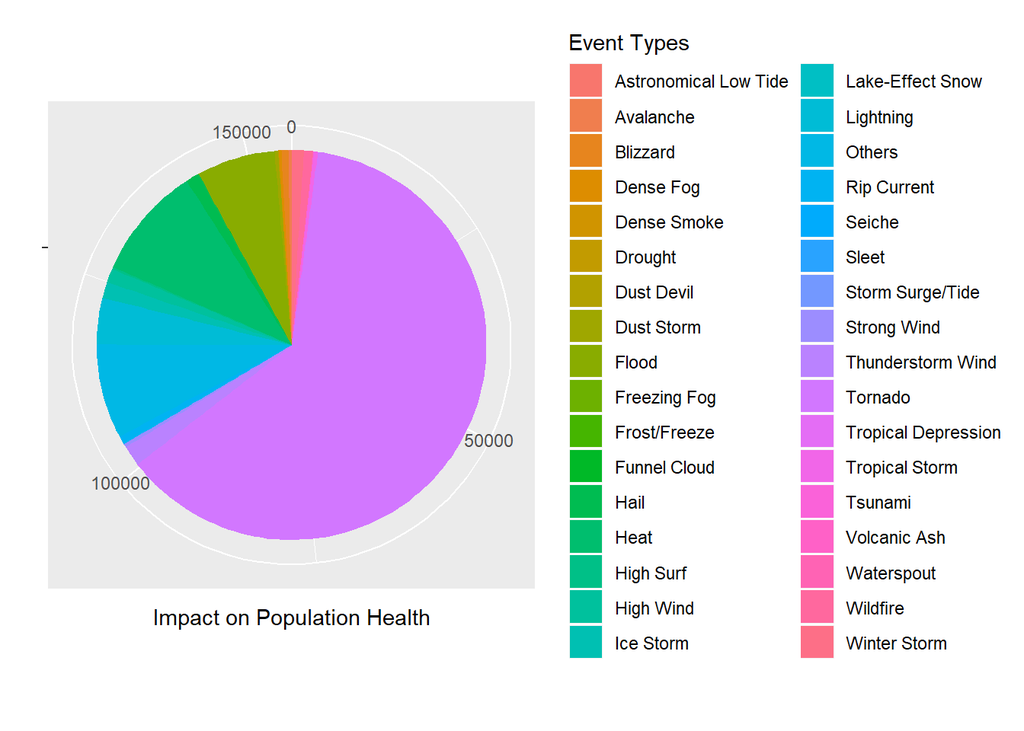

```r
# Visualizing table
g.harm <- ggplot(data = stormData.harm.analysis, aes(x = "", y = pop.harm, fill = EVTYPE)) + geom_bar(stat = "identity")
g.harm + coord_polar("y", start = 0) + labs(x = "", y = "Impact on Population Health", fill = "Event Types")
```

Using the pie chart and the table above, we can conlcude that Tornado causes most harm to the population health. For the period of year 1950 to year 2011, Tornado has harmed **9,7068** lives accross all states. ### Which type of event has the greatest economic consequece?

```r
head(stormData.damage.analysis, n = 10)
```

```
## # A tibble: 10 x 2
##    EVTYPE                eco.cq
##    <chr>                  <dbl>
##  1 Flood          179909849807.
##  2 Others         146462556735
##  3 Tornado         59010559546.
##  4 Hail            19160928866.
##  5 Drought         15018927780
##  6 Ice Storm        8968141360
##  7 Tropical Storm   8409286550
##  8 High Wind        6787142925
##  9 Winter Storm     6781441251
## 10 Heat             6225900932.
```

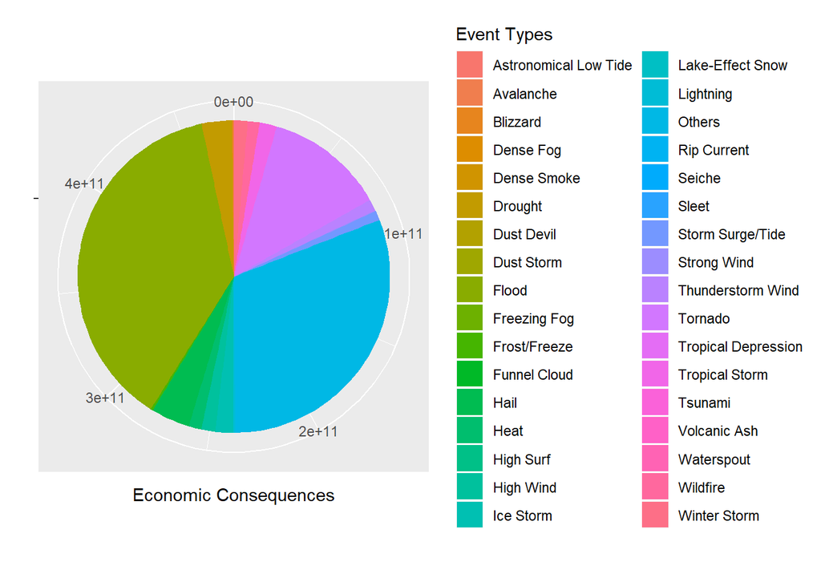

```r
# Visualizing table
g.eco <- ggplot(data = stormData.damage.analysis, aes(x = "", y = eco.cq, fill = EVTYPE)) + geom_bar(stat = "identity")
g.eco + coord_polar("y", start = 0) + labs(x = "", y = "Economic Consequences", fill = "Event Types")
```